# Word Prediction Application - Stupid Backoff N-Gram Method

Ryan Wissman  
10/8/2016

### Introduction

Final application submission for the Johns Hopkins Coursera Data Science Capstone

- Word prediction application created using Swiftkey datasets of twitter, news, and blog natural language text
- This application utilizes the N-gram model of natural language processing to take a user input and essentially “guess” the next relevant word in the string
- The final prediction model utilizes the Stupid Backup model in its final implementation.
- There are limitations with this method and I was only able to use a very small subset of the data as applicaton database size and processing time were of utmost concern

Application link: https://speedy3d.shinyapps.io/shiny-prediction-app/

### Using the application

- The application is fairly straightfoward in that the user will input a string of text on the left, on the right the predicted next word will be highlighted in green. Screenshot is below:

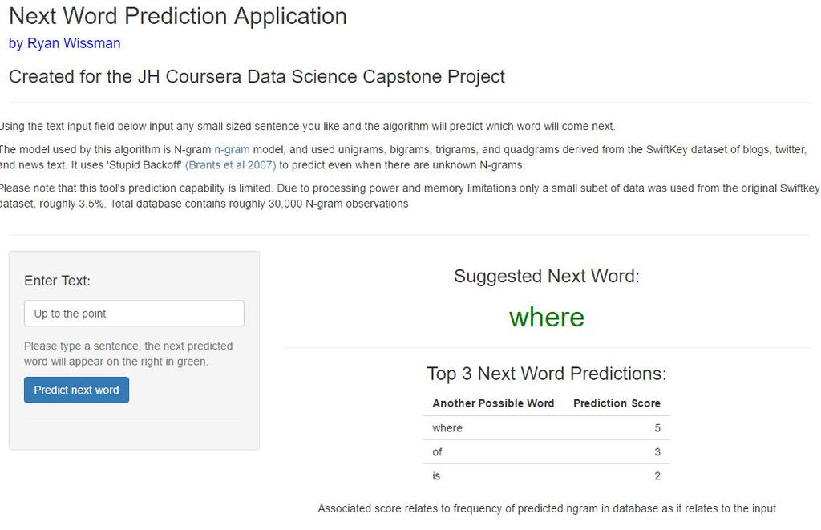

### The Algorithm - Stupid Backoff

The application uses the Stupid Backoff model described by Brants et al 2007: http://www.aclweb.org/anthology/D07-1090.pdf

This model has a few advantages over other models, namely:

- **Fast**: Uses far fewer resources and is easier to implement than other algorithms such as Katz's Backoff Model
- **Accurate**: Good quality that approachs other methods such as Kneser-Ney

### Designed for Speed

Due to limited computing resources this applicaion needed to be designed for speed. Thus a few choices were made that limited the accuracy and depth of the prediction database. Thus the following choices were made:

- I utilized a SQLite database to store the n-grams and frequency table. The database size was limited to about 10mb to maintain high speed
- Due to memory and computing limitations only 3.5% of the original SwiftKey text files (twitter, blogs, and news) were used. If a larger portion was used I would run out of memory when calculating and sorting the n-gram frequency tables
- Up to quadgrams are used. The Stupid Backoff method could utilize higher order n-grams, but due to the the limiations of my computer and the Shiny hosting service quadgrams (4) were the highest order n-grams used for this application

### References

Below are some of the numerous resources utilized in the creation of this application.

- Original code used for processing the SQLite databased used by the application can be found here: https://github.com/speedy3d/Coursera-DataScienceCapstone
- Stupid Backoff model described by Brants et al 2007: http://www.aclweb.org/anthology/D07-1090
- Information related to natural language processing: https://en.wikipedia.org/wiki/Natural_language_processing